# Clase 2 - Guía de trabajo variables aleatorias continuas y discretas

Curso Introducción al Análisis de datos con R para la Acuicultura.

Dr. José A. Gallardo Matus y Dra. María Angélica Rueda

Pontificia Universidad Católica de Valparaíso  
jose.gallardo@pucv.cl

09 July 2022

### **Introducción**

**¿Cuál es la diferencia entre variable y dato?**

Las **variables** son las características que se pueden medir en un individuo o en un ambiente y los **datos** son los valores que puede tomar esa variable.

**¿Qué es una variable aleatoria?**

Es una variable cuyo valor se determina por el azar. Las variables aleatorias se representan por letras mayúsculas (**X**) y sus valores numéricos por letras minúsculas ($x_i$).

### **Clasificación de variables cuantitativas**

[output not shown]

### **Clasificación de variables cualitativas o categóricas**

| **Tipo de variable** | **Descripción** |
| --- | --- |
| **Variables nominales:** | Sus valores representan categorías que no obedecen a una clasificación intrínseca. |
| **Variables ordinales:** | Sus valores representan categorías con alguna clasificación intrínseca. |

### **Distribución de una variable**

*Distribución empírica (observación)*: Los datos de una muestra, obtenidos de forma aleatoria de una población, pueden ser usados para observar su comportamiento o distribución.

*Distribución normal*: Las variables cuantitativas continuas podrían seguir una distribución normal.

### **¿Cómo puedo observar el comportamiento de una variable?**

En la siguiente tabla se muestran varias **funciones clave** para poder observar o predecir el comportamiento de una variable aleatoria.

| **Librería** | **Función** | **Descripción** |
| --- | --- | --- |
| base | **table()** | Tabla de distribución de frecuencia para factores. |
| base | **plot()** | Gráfico x-y de puntos “p”, líneas “l” o ambas “b”. |
| graphics | **hist()** | Histograma para variables cuantitativas |
| graphics | **boxplot()** | Gráfico de cajas y bigotes |
| graphics | **barplot()** | Gráfico de barras |

### **¿Qué puedo medir de una variable aleatoria continua?**

| **Librería** | **Función** | **Descripción** |
| --- | --- | --- |
| base | **mean()** | Media aritmética |
| base | **range()** | Rango |
| stats | **median()** | Mediana |
| stats | **var()** | Varianza |
| stats | **sd()** | Desviación estándar |
| stats | **quantile()** | Concentración de datos en cuantiles |
| stats | **cor()** | Correlación con otra variable |

### **¿Cómo puedo simular números aleatorios con distribución normal?**

| **Librería** | **Función** | **Descripción** |
| --- | --- | --- |
| stats | **rnorm(n, mean, sd)** | Genera (n) números aleatorios para la distribución normal con promedio (mean) y desviación estandar (sd) |

### **Distribuciones posibles para variables aleatorias dicretas**

**Distribución Bernoulli**: la distribución Bernoulli (o distribución dicotómica), nombrada así por el matemático suizo Jacob Bernoulli, es una distribución de probabilidad discreta, donde la variable aleatoria X toma el valor de 1 (**X**=1), cuando ocurre el suceso **éxito** y cuya probabilidad asociada es $p$ y si toma X el valor de cero (**X**=0) ocurre el suceso **fracaso** con probabilidad $q=1-p$. En notación, lo comentado anteriormente sería expresado de la siguiente forma: **P(X=1) =** $p$ (Probabilidad de éxito) y **P(X=0) =** $1-p$ (Probabilidad de fracaso). *Nota*: *La distribución Bernoulli es un caso particular de la distibución binomial cuando* $n=1$, *es decir, solo se hace una vez un ensayo*.

**Distribución Binomial**: la distribución Binomial o distribución binómica es una distribución de probabilidad discreta que cuenta el número de éxitos en una secuencia de $n$ ensayos de Bernoulli independientes entre sí, con una probabilidad fija $p$ de ocurrencia de éxito entre los ensayos y que tiene una probabilidad de fracaso $q=1-p$.

**Distribución binomial negativa**: la distribución Binomial negativa es una distribución de probabilidad discreta que incluye a la distribución de Pascal. Es utilizada en procesos en los cuales se ve necesaria la repetición de ensayos hasta conseguir un número de casos favorables (r-ésimo éxito, es decir, r=2,3,4, etc).

### **¿Cómo puedo simular números aleatorios con distribución Binomial y Bernoulli?**

| **Librería** | **Función** | **Descripción** |
| --- | --- | --- |
| stats | **rbinom(n, size, prob)** | Genera (n) números aleatorios para la distribución binomial con parámetros tamaño (size) y probabilidad de éxito de un ensayo (prob) |
| Rlab | **rbern()** | Simular variable aleatoria Bernoulli |
| MASS | **rnegbin (n, mu, theta)** | Genera (n) números aleatorios para la distribución de binomial negativa con parámetros promedio (mu) y varianza (mu + mu$^{2}$ / theta), donde theta es un número arbitrario para estimar la varianza |

### **Objetivos de aprendizaje**

Los objetivos de aprendizaje de esta guía son:

**1**. Observar la distribución de una variable aleatoria continua (*e.g.* Distribución Normal) y variable aleatoria discreta (*e.g.* Distribución Bernoulli, Distribucción Binomial).

## **Ejercicios**

### **Ejercicio 1.** **Elaborar un Script de R (Archivo .R)**

Elabore un archivo o file con extensión **.R** usando la barra de herramientas de **Rstudio**. Selecciona **File > New file > R script**. Utilice el siguiente ejemplo para completar la información de **metadatos** del script.

```
# --------------------------------------------------------------------
# Clase 02 - Guia variables aleatorias continuas y discretas.
# Su nombre:
# 09 Julio 2022.
# Curso Introducción al Análisis de datos con R para la Acuicultura.
# --------------------------------------------------------------------
```

Luego, guarde inmediatamente su script como **script_2_nombre_apellido.R**.

### **Ejercicio 2.** **Configuración de librerías**

Debajo del **metadatos** habilite el paquete **readxl**, **Rlab** y **MASS** usando la función **library()**. Note que los paquetes **base**, **stats**, **utils** y **graphics** ya están habilitados.

```r
knitr::opts_chunk$set(echo = FALSE)
library(readxl)
library(Rlab)
library(MASS)
```

### **Ejercicio 3.** **Peso y talla de Salmones del Atlántico.**

El set de datos **datos.xlsx** contiene información de peso (**Peso**) y talla (**Talla**) de 100 salmones del Atlántico un estanque, los cuales se clasificaron según su sexo en **Hembra** o **Macho**.

Cree un objeto llamado **salmones** e importe el set de datos **datos.xlsx** usando la función **read_excel** de la librería **readxl**.

Explore el set de datos algunas funciones de la librería **{utils}** **head()**, **tail()**, **str()** y de la librería **{base}** **summary**.

```
## # A tibble: 6 × 4
##   Animal Talla  Peso Sexo
##    <dbl> <dbl> <dbl> <chr>
## 1      1  72.3 2821. Hembra
## 2      2  79.8 5639. Macho
## 3      3  62.4 5263. Hembra
## 4      4  75.1 7397. Macho
## 5      5  85.8 6742. Macho
## 6      6  84.7 6755. Hembra
```

```
## # A tibble: 6 × 4
##   Animal Talla  Peso Sexo
##    <dbl> <dbl> <dbl> <chr>
## 1     95  78.7 6847. Macho
## 2     96  81.9 7545. Macho
## 3     97  71.5 6075. Macho
## 4     98  76.7 7395. Macho
## 5     99  74.9 5402. Macho
## 6    100  67.4 7249. Hembra
```

```
## tibble [100 × 4] (S3: tbl_df/tbl/data.frame)
##  $ Animal: num [1:100] 1 2 3 4 5 6 7 8 9 10 ...
##  $ Talla : num [1:100] 72.3 79.8 62.4 75.1 85.8 ...
##  $ Peso  : num [1:100] 2821 5639 5263 7397 6742 ...
##  $ Sexo  : chr [1:100] "Hembra" "Macho" "Hembra" "Macho" ...
```

```
##      Animal           Talla            Peso          Sexo
##  Min.   :  1.00   Min.   :61.32   Min.   :2627   Length:100
##  1st Qu.: 25.75   1st Qu.:73.18   1st Qu.:5065   Class :character
##  Median : 50.50   Median :76.82   Median :5825   Mode  :character
##  Mean   : 50.50   Mean   :77.03   Mean   :5864
##  3rd Qu.: 75.25   3rd Qu.:80.49   3rd Qu.:6656
##  Max.   :100.00   Max.   :91.10   Max.   :8636
```

### **Ejercicio 4.** **Corrección de variables**

Note que en el ejercicio anterior la variable **Sexo** fue codificada como caracter o texto (chr) en vez de factor. Use la función **as.factor(salmones$Sexo)** para indicar que Sexo es un factor de clasificación. Vuelva a ejecutar los comandos **summary()** y **str()** para comprobar que las variables están adecuadamente codificadas.

```
##      Animal           Talla            Peso          Sexo
##  Min.   :  1.00   Min.   :61.32   Min.   :2627   Hembra:51
##  1st Qu.: 25.75   1st Qu.:73.18   1st Qu.:5065   Macho :49
##  Median : 50.50   Median :76.82   Median :5825
##  Mean   : 50.50   Mean   :77.03   Mean   :5864
##  3rd Qu.: 75.25   3rd Qu.:80.49   3rd Qu.:6656
##  Max.   :100.00   Max.   :91.10   Max.   :8636
```

```
## tibble [100 × 4] (S3: tbl_df/tbl/data.frame)
##  $ Animal: num [1:100] 1 2 3 4 5 6 7 8 9 10 ...
##  $ Talla : num [1:100] 72.3 79.8 62.4 75.1 85.8 ...
##  $ Peso  : num [1:100] 2821 5639 5263 7397 6742 ...
##  $ Sexo  : Factor w/ 2 levels "Hembra","Macho": 1 2 1 2 2 1 1 2 1 1 ...
```

### **Ejercicio 5.** **Observar el comportamiento de una variable**

A partir del set de datos **salmones** elabore un histograma y un boxplot de la variable cuantitativa continua **Peso**. Use las funciones **hist()**, **boxplot()**. Incluya títulos y leyenda de los ejes con los argumentos *col=““*,* main =”“* y *xlab=““*.

Investigue y use este comando **par(mfrow=c(1,2))** para unir las gráficas en un solo panel con dos columnas.

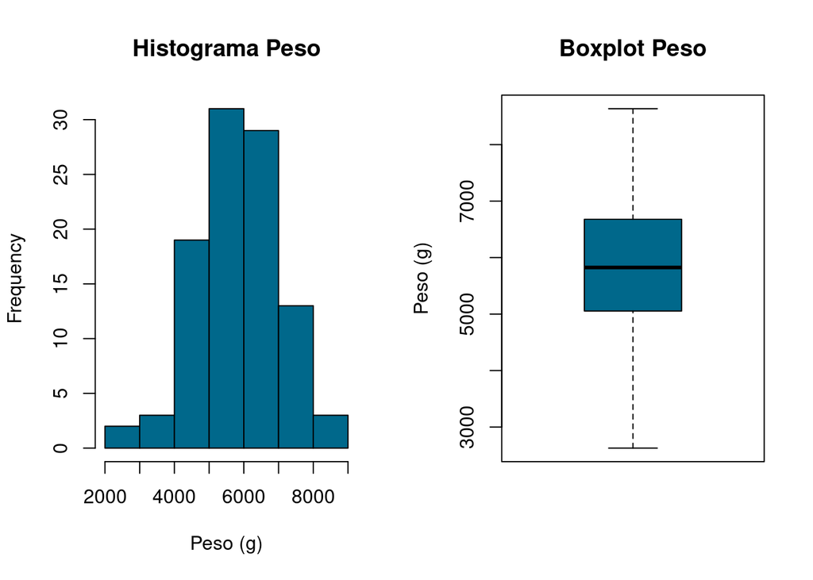

### **Ejercicio 6.** **Métricas del set de datos salmones**

Calcule las siguientes métricas del set de datos: promedio, desviación estándar, rango y cuantiles usando las funciones: **mean()**, **sd()**, **range()** y **quantile()**.

```
## [1] 5864.144
```

```
## [1] 1171.266
```

```
## [1] 2626.997 8636.039
```

```
##       0%      25%      50%      75%     100%
## 2626.997 5064.840 5824.989 6655.946 8636.039
```

### **Ejercicio 7.** **Diferencias entre machos y hembras.**

Finalmente, elabore un boxplot para comparar la diferencia de peso entre machos y hembras. Use la formula **boxplot(y ~ x)**, donde y es la variable **Peso** y x es la variable **Sexo**.

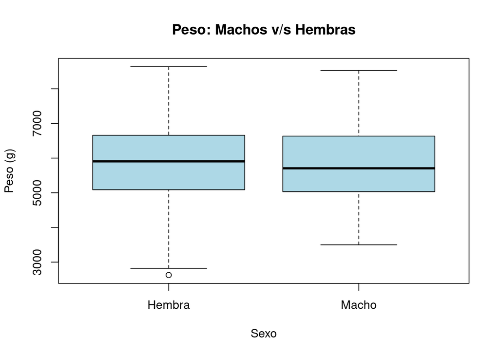

### **Ejercicio 8.** **Veneno paralizante de los mariscos.**

*Alexandrium catenella* es una microalga tóxica que produce el veneno paralizante de los mariscos (VPM). En Chile las intoxicaciones por VPM entre 1972-2002 generaron 456 enfermos y 30 fallecidos (total = 486). A partir de estos antecedentes responda.

**a).** ¿Que tipo de variable y distribución mejor representa a la intoxicación por VPM?

```r
# "Variable aleatoria discreta con distribución Binomial"
```

**b).** ¿Calcule la letalidad por VPM en Chile?

```r
LT_VPM <- 30 / 486
LT_VPM
```

```
## [1] 0.0617284
```

**c).** Se ha reportado un intoxicación masiva de veneno paralizante de los mariscos en Calbuco que dio como resultado 80 personas intoxicadas. ¿Cuántas personas se recuperarán (0) y cuantas morirán (1) por esta intoxicación?.

Para responder primero nosotros crearemos para usted un objeto denominado **rvpm** y simularemos el resultado de la intoxicación usando la función **rbinom()**. Usaremos **print()** para observar los datos simulados.

```r
# set.seed function sets the starting number used to generate a sequence of random numbers
set.seed(123)

# n representará el número de intoxicados
n <- 80

# p representará probabilidad de morir con base a datos de letalidad entre 1972 y 2002
p <- 0.0617

# q representa la probabilidad de sobrevivir.
q <- 1-p

# Objeto rvmp contiene la probabilidad de morir = 1 o sobrevivir = 1 para una población simulada de 80 intoxicados.
rvpm <- rbinom(n, size=1, prob=0.0617)

# Explica datos generados
print(rvpm)
```

```
##  [1] 0 0 0 0 1 0 0 0 0 0 1 0 0 0 0 0 0 0 0 1 0 0 0 1 0 0 0 0 0 0 1 0 0 0 0 0 0 0
## [39] 0 0 0 0 0 0 0 0 0 0 0 0 0 0 0 0 0 0 0 0 0 0 0 0 0 0 0 0 0 0 0 0 0 0 0 0 0 0
## [77] 0 0 0 0
```

**d).** Usando la función **table()** represente la frecuencia esperada de recuperados y fallecidos.

```r
table(rvpm)
```

```
## rvpm
##  0  1
## 75  5
```

**e).** Represente en un histograma la frecuencia de recuperados y fallecidos.

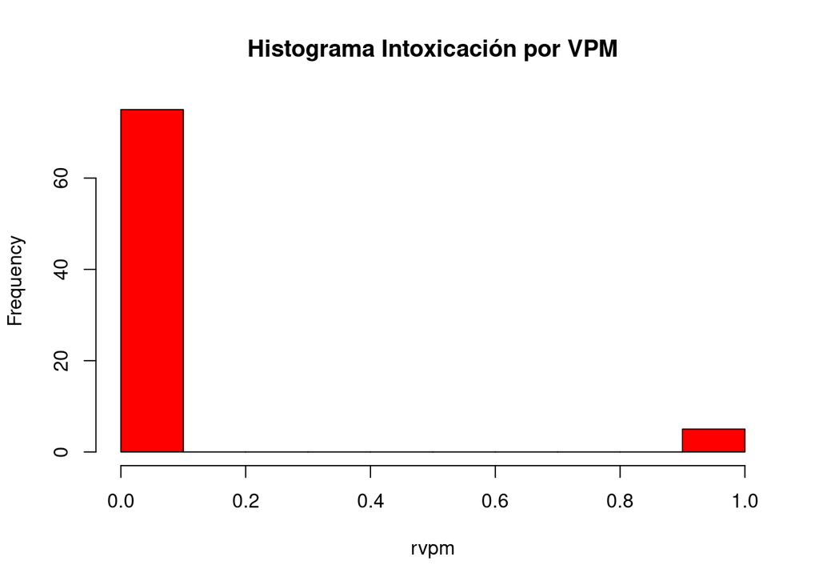

```r
hist(rvpm, col="red", main = "Histograma Intoxicación por VPM")
```

**f).** Investigue como se calcula el promedio y la varianza de una variable con distribución binomial. Calcule ambos parámetros para la población de estudio.

Promedio de fallecidos.

```r
n*p
```

```
## [1] 4.936
```

Varianza de fallecidos.

```r
n*p*q
```

```
## [1] 4.631449
```

### **Ejercicio 9.** **Parásitos en salmones.**

La abundancia de parásitos como el piojo de mar *Caligus rogercresseyi* en los salmones de cultivo puede ser considerada como una variable distreta con distribución binomial negativa. Esto significa que uno suele observar muchos peces con pocos parásitos (ej= 0 o 1) y pocos peces con muchos parásitos. Un estudio demostró que el promedio de la abundancia de parásitos fue de 25 con un rango de 0 a 90.

**a).** Cree un objeto llamado “caligus” para representar el número de parásitos en los peces. Simule una muestra aleatoria con distribución binomial negativa con la función **rnegbin()**. Considere 500 peces con una media de 25 parásitos. Para simular la varianza debe asignar valores arbitrarios a theta entre 1 y 5 hasta obtener un promedio y rango aproximado al estudio antes descrito (promedio de 25 y rango de 0 a 90).

Generar una muestra desde la población en estudio

```r
set.seed(123) #es una semilla para obtener los mismos resultados cada vez que se haga la simulación de los datos
# n = 500 animales
# mu = 25 (parásitos por pez)
# theta = 1 (cambie este valor hasta encontrar uno que se ajuste a los datos observados)
caligus <- rnegbin (500, 25, 5)
head(caligus, 20)
```

```
##  [1] 20 37  5 26 38 23 13  8 26 33 37 23  7 35 31 24 22 17 10 19
```

```r
mean(caligus)
```

```
## [1] 24.014
```

**b).** Use las funciones head() y range() para observar sus datos. Compare las funciones quantile() y summary().

```r
head(caligus)
```

```
## [1] 20 37  5 26 38 23
```

```r
range(caligus)
```

```
## [1]  2 71
```

```r
quantile(caligus)
```

```
##   0%  25%  50%  75% 100%
##    2   16   22   30   71
```

```r
summary(caligus)
```

```
##    Min. 1st Qu.  Median    Mean 3rd Qu.    Max.
##    2.00   16.00   22.00   24.01   30.00   71.00
```

¿Que parámetro representa mejor los datos, la mediana o la media?

```r
"La mediana representa mejor los datos puesto que la media es muy influenciable por los valores extremos"
```

```
## [1] "La mediana representa mejor los datos puesto que la media es muy influenciable por los valores extremos"
```

**c).** A partir de la simulación anterior elabore un resumen del conteo de parásitos por pez usando **table(caligus)**. Luego elabore un gráfico de barras **barplot()**y una gráfica de cajas y bigotes **boxplot()**. Use la función **par(mfrow=c(1,2))** para generar las gráficas en una sola fila y con 2 columnas.

```
## caligus
##  2  4  5  6  7  8  9 10 11 12 13 14 15 16 17 18 19 20 21 22 23 24 25 26 27 28
##  1  3  4  5  6  5 11 17 10  8 13 20 21 18 19 17 15 21 17 24 14 15 15 21 17 17
## 29 30 31 32 33 34 35 36 37 38 39 40 41 42 43 44 45 46 47 48 49 50 51 52 53 57
##  8 14  7 13 11  4  9  7 11  8  6  4  9  3  2  3  1  3  5  2  2  2  1  1  3  2
## 59 60 62 68 71
##  1  1  1  1  1
```

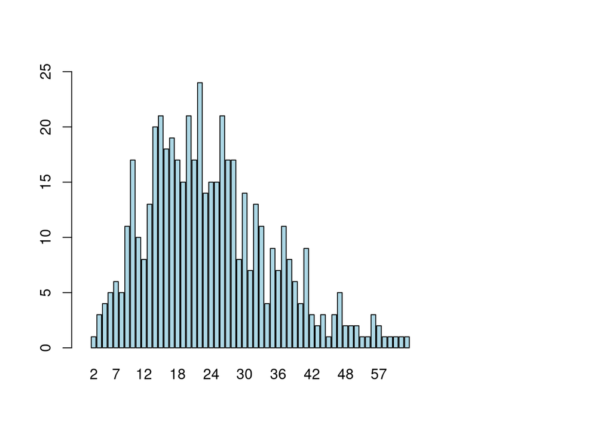

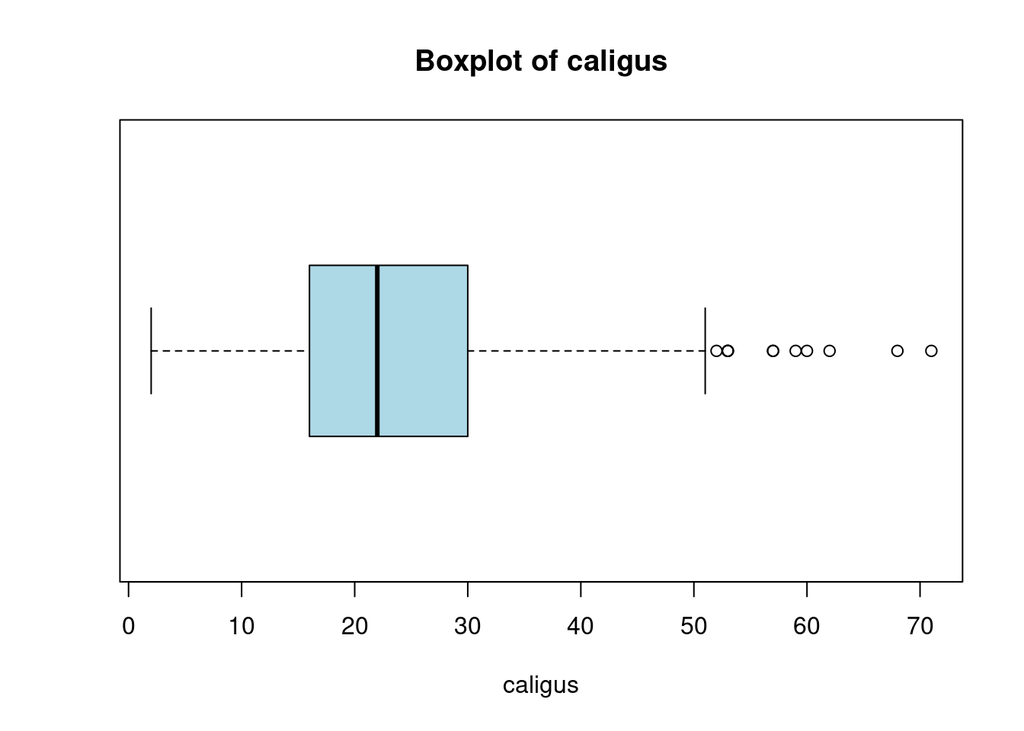

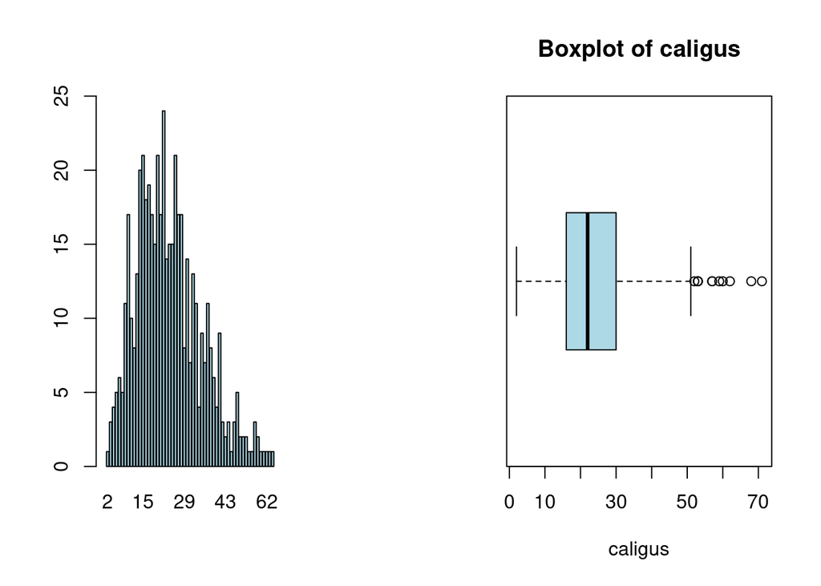

```r
par(mfrow=c(1,2))
barplot(table, col="lightblue", xlim = c(0, 100), ylim=c(0,25))
boxplot(caligus, col="lightblue", main="Boxplot of caligus", horizontal = TRUE, xlab="caligus")
```